# 5.1 - Classification with more than two classes

Sajini Arumugam

### **Comprehension Check: Trees and Random Forests**

#### **Question 1**

Create a simple dataset where the outcome grows 0.75 units on average for every increase in a predictor, using this code:

```r
library(rpart)
n <- 1000
sigma <- 0.25
set.seed(1, sample.kind = "Rounding")
x <- rnorm(n, 0, 1)
y <- 0.75 * x + rnorm(n, 0, sigma)
dat <- data.frame(x = x, y = y)
```

Which code correctly uses rpart() to fit a regression tree and saves the result to fit?

```r
fit <- rpart(y ~ ., data = dat)
```

#### **Question 2**

Which of the following plots has the same tree shape obtained in Q1?

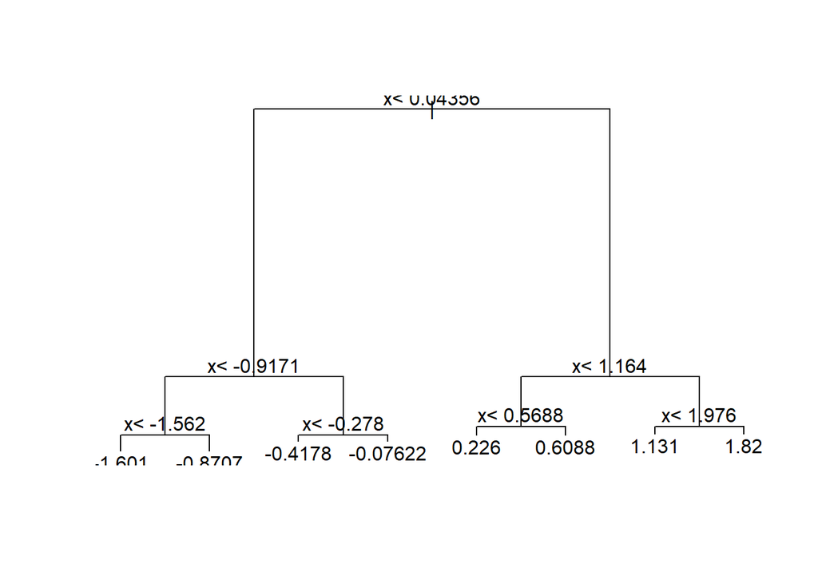

```r
plot(fit)
text(fit)
```

#### **Question 3**

Below is most of the code to make a scatter plot of y versus x along with the predicted values based on the fit.

```r
library(dplyr)
```

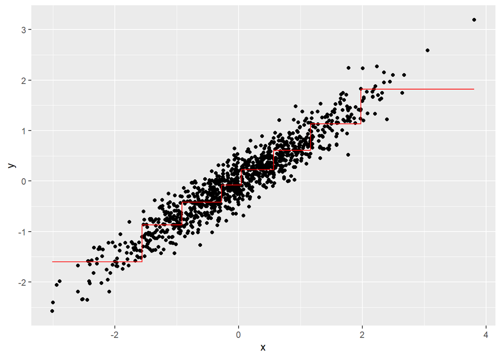

```r
library(ggplot2)
dat %>%
    mutate(y_hat = predict(fit)) %>%
    ggplot() +
    geom_point(aes(x, y)) +
    geom_step(aes(x, y_hat), col=2)
```

```r
geom_step(aes(x, y_hat), col=2)
```

```
## mapping: x = ~x, y = ~y_hat
## geom_step: direction = hv, na.rm = FALSE
## stat_identity: na.rm = FALSE
## position_identity
```

#### **Question 4**

Now run Random Forests instead of a regression tree using randomForest() from the randomForest package, and remake the scatterplot with the prediction line. Part of the code is provided for you below.

```r
library(randomForest)
```

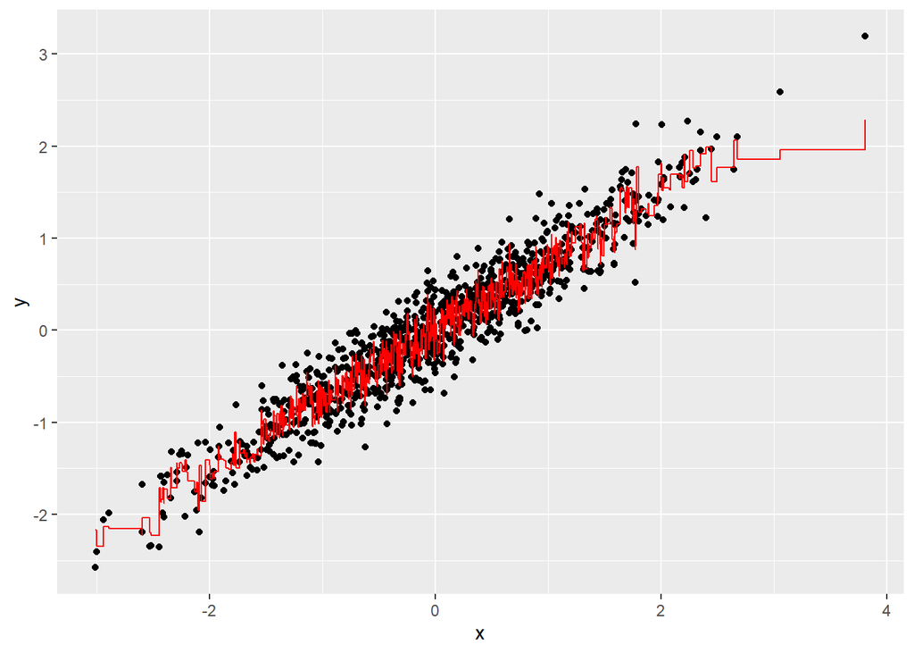

```r
fit <-randomForest(y ~ x, data = dat)
dat %>%
    mutate(y_hat = predict(fit)) %>%
    ggplot() +
    geom_point(aes(x, y)) +
    geom_step(aes(x, y_hat), col = "red")
```

What code should replace #BLANK in the provided code?

`randomForest(y ~ x, data = dat)`

#### **Question 5**

Use the plot() function to see if the Random Forest from Q4 has converged or if we need more trees.

Which of these graphs is produced by plotting the random forest?

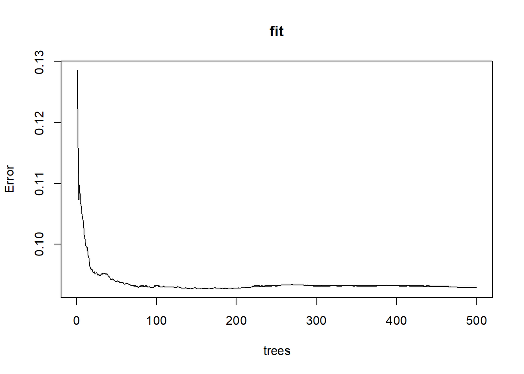

```r
plot(fit)
```

#### **Question 6**

It seems that the default values for the Random Forest result in an estimate that is too flexible (unsmooth). Re-run the Random Forest but this time with a node size of 50 and a maximum of 25 nodes. Remake the plot.

Part of the code is provided for you below.

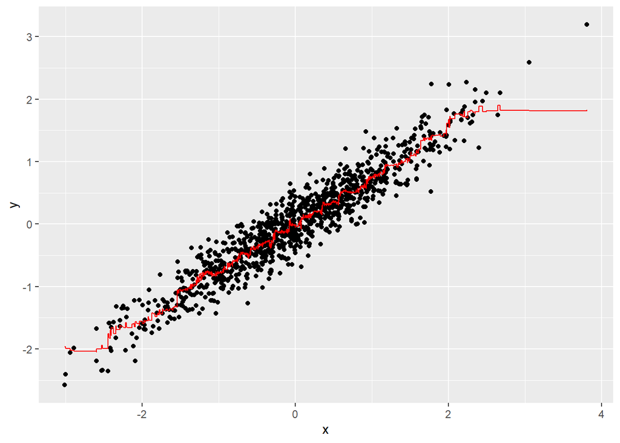

```
randomForest(y ~ x, data = dat, nodesize = 50, maxnodes = 25)
```

```r
library(randomForest)
fit <- randomForest(y ~ x, data = dat, nodesize = 50, maxnodes = 25)
dat %>%
    mutate(y_hat = predict(fit)) %>%
    ggplot() +
    geom_point(aes(x, y)) +
    geom_step(aes(x, y_hat), col = "red")
```